# Lab 1 Guía Práctica Modelos Basados en Captura

Luis A. Cubillos

17 Enero 2022

## Objetivos

### General

Aplicar algunos métodos de evaluación con datos limitados analizar el estatus y reconocer limitaciones.

### Específicos

1. Evaluación del estatus aplicando un método basado sólo en capturas.

## Tópicos

1. Series de tiempo de capturas.
2. Clasificación de estatus en base a $C_max$.
3. Métodos basados sólo en captura (Only-catch).

## Datos

1. Capturas anuales de reineta en Chile, periodo 1994-2020.
2. Capturas anuales de jibia, *Dosidicus gigas*, en el Pacífico Suroriental (Area 87). Datos recopilados de distintas fuentes por Payá (2018).

## Métodos

1. CMSY2 (Froese et al., 2017)
2. OCOM (Zhou et al., 2017a)
3. zBRT (Zhou et al., 2017b)

### Instalación de packages

```r
devtools::install_github("cfree14/datalimited2")
```

## Métodos basados en datos de captura

Los modelos que se utilizarán son tres de los más comunes, y consisten en estimaciones de estatus según el modelo de excedentes de producción logístico para el modelo de biomasa dinámica dada por:

$$B_{t+1}=B_t + rB_t(1-B_t/k)-C_t$$

donde $B_t$ es la biomasa del stock en el año $t$, $r$ es la tasa intrinseca de crecimiento poblacional (i.e., $r_{max}$), $k$ es la capacidad de carga (no confundir con el coeficiente de crecimiento corporal de von Bertalanffy), en tanto que $C_t$ es la captura en el año $t$.

El marco biológico para la explotación por defecto, viene dado por los siguientes puntos biológicos de referencia:

Biomasa inexplotada: $B_0 = k$

Biomasa objetivo: $B_{RMS}=k/2$

Biomasa límite: $B_{lim}=k/4$

Rendimiento máximo sostenido: $RMS=rK/4$

Mortalidad por pesca objetivo: $F_{RMS}=r/2$

### Datos de captura

Los datos de captura de reineta consisten en una serie de tiempo que cubre 27 años, desde 1994 a 2020, i.e.,

```r
reineta <- structure(list(
  yr = 1994:2020,
  ct = c(1186, 3930, 5585, 5998, 6332, 6828, 8159, 15156, 4429, 2645, 3764, 12707, 2517, 3743, 6160, 15199, 16977, 28814, 23079, 11955, 35975, 34218, 27586, 25267, 28175, 44288, 38109)),
  .Names = c("yr", "ct"),
  class = "data.frame",
  row.names = 1:27)
```

Un gráfico de las capturas clásico se puede representar por:

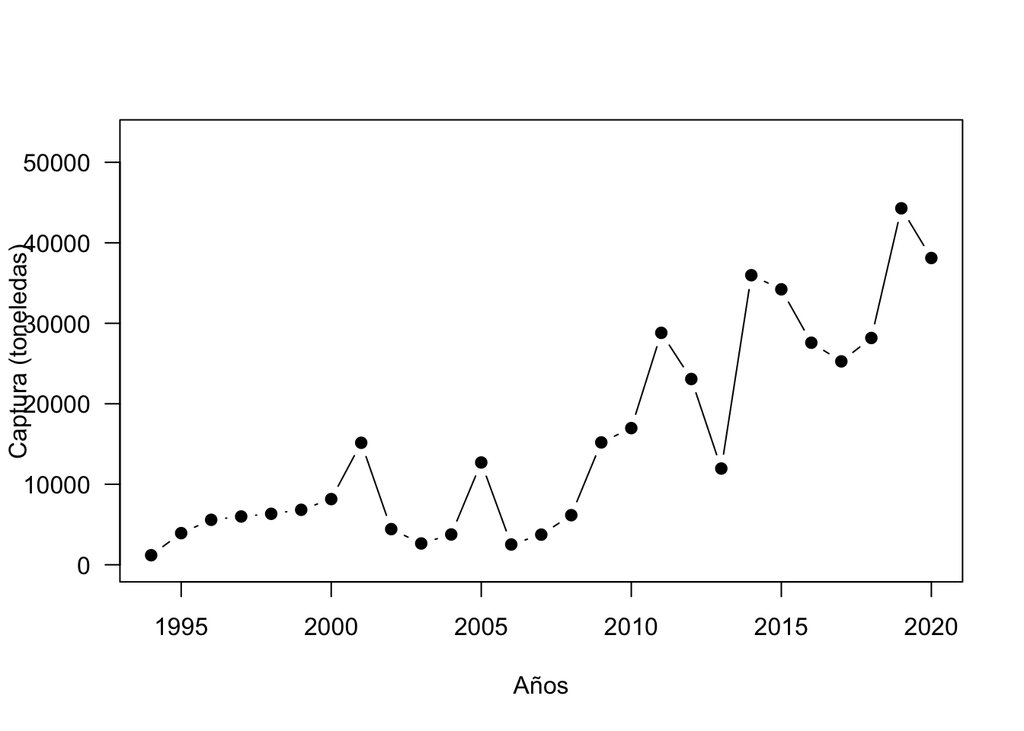

```r
library(datalimited2)
yt <- reineta$ct
captura_reineta <- ts(yt,start = 1994,frequency = 1)
plot(captura_reineta,ty="b",pch=19,ylim=c(0,max(reineta$ct)*1.2),las=1,ylab="Captura (toneledas)",xlab="Años")
```

#### Modelos

**m1**: CMSY2

**m2**: OCOM

**m3**: zBRT

#### Estimación

El modelo CMSY2 corresponde al método propuesto por Froese et al. (2017) en base a indicadores de resiliencia que pueden ser consultados en FISHBASE, mediante la función `resilience(species="Brama australis")`. Sin embargo, la resiliencia no está disponible para esta especie y se asume que puede ser alta. Luego, la estimación es:

```r
catch = reineta$ct
yr = reineta$yr
m1 = cmsy2(year=yr, catch=catch, resilience="High")
```

```
## startbio= 0.2 0.6 default , intbio= 2015 0.5 0.9 default , endbio= 0.4 0.8 default
## First Monte Carlo filtering of r-k space with  10000  points...
##
## Found  31310  viable trajectories for 3474  r-k pairs
## ---------------------------------------
## Catch data used from years 1994 - 2020
## Prior initial relative biomass = 0.2 - 0.6 default
## Prior intermediate rel. biomass= 0.5 - 0.9 in year 2015 default
## Prior final relative biomass   = 0.4 - 0.8 default
## Prior range for r = 0.6 - 1.5 default , prior range for k = 49.1 - 737
##
## Results of CMSY analysis
## -------------------------
## Altogether 31310 viable trajectories for 3474  r-k pairs were found
## r   = 1.19 , 95% CL = 0.957 - 1.48 , k = 126 , 95% CL = 76.7 - 207
## MSY = 37.5 , 95% CL = 21.8 - 64.5
## Relative biomass in last year = 0.701 k, 2.5th perc = 0.424 , 97.5th perc = 0.798
## Exploitation F/(r/2) in last year = 0.725
##
## -------------------------------------------------------------
## Fmsy = 0.596 , 95% CL = 0.479 - 0.741 (if B > 1/2 Bmsy then Fmsy = 0.5 r)
## Fmsy = 0.596 , 95% CL = 0.479 - 0.741 (r and Fmsy are linearly reduced if B < 1/2 Bmsy)
## MSY  = 37.5 , 95% CL = 21.8 - 64.5
## Bmsy = 62.9 , 95% CL = 38.3 - 103
## Biomass in last year = 88.2 , 2.5th perc = 53.3 , 97.5 perc = 100
## B/Bmsy in last year  = 1.4 , 2.5th perc = 0.847 , 97.5 perc = 1.6
## Fishing mortality in last year = 0.432 , 2.5th perc = 0.38 , 97.5 perc = 0.715
## Exploitation F/Fmsy  = 0.725 , 2.5th perc = 0.637 , 97.5 perc = 1.2
```

El diagnóstico del ajuste se obtiene mediante la función:

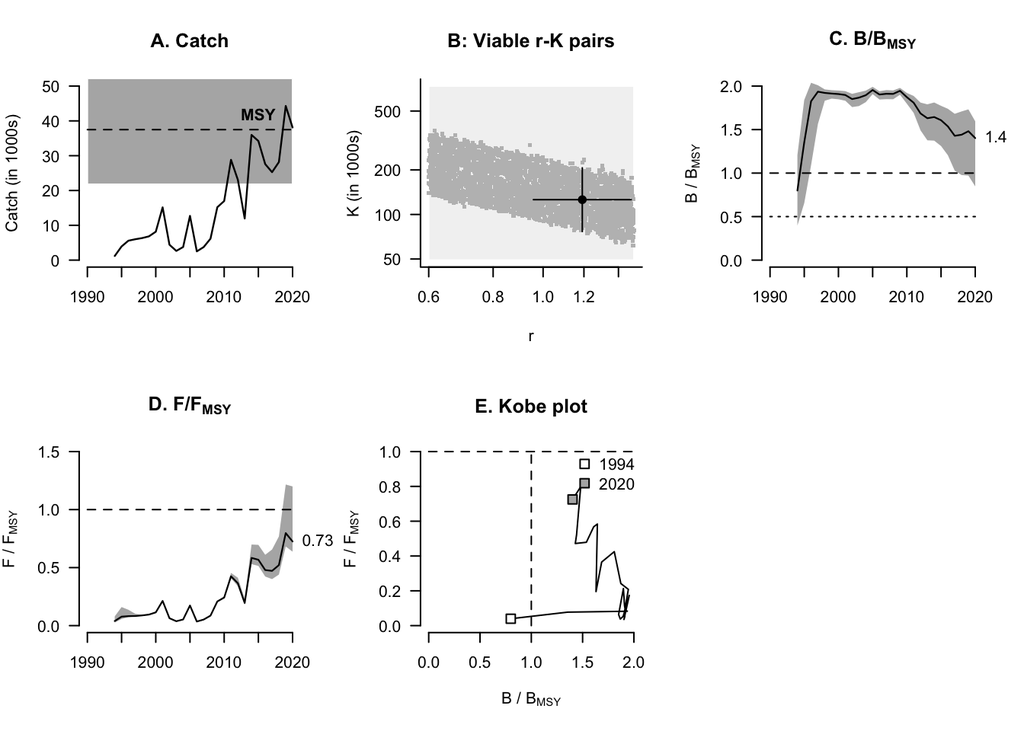

```r
plot_dlm(m1)
```

La estimación de la biomasa con límites de confianza se obtiene de la siguiente manera:

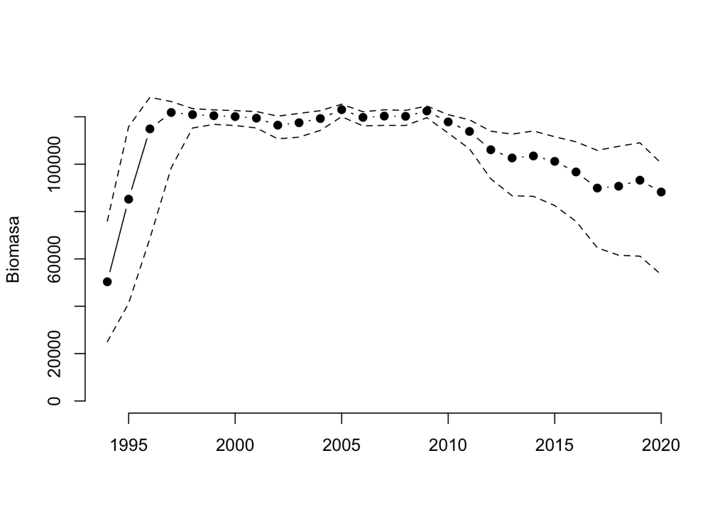

```r
m1.Bt = m1$ref_ts$b
m1.Bt_l = m1$ref_ts$b_lo
m1.Bt_h = m1$ref_ts$b_hi
plot(yr, m1.Bt, type="b", bty="n", pch=19,xlab="",ylab="Biomasa",ylim=c(0,max(m1.Bt_h)))
lines(yr, m1.Bt_l, lty=2)
lines(yr, m1.Bt_h, lty=2)
```

Para extraer los puntos biológicos de referencia, se utilza la siguiente función:

```r
CMSY1_ref_pts = m1[["ref_pts"]]
knitr::kable(CMSY1_ref_pts)
```

| param | est | lo | hi |
| --- | --- | --- | --- |
| r | 1.19e+00 | 9.57e-01 | 1.48e+00 |
| k | 1.26e+05 | 7.67e+04 | 2.07e+05 |
| msy | 3.75e+04 | 2.18e+04 | 6.45e+04 |
| fmsy | 5.96e-01 | 4.79e-01 | 7.41e-01 |
| bmsy | 6.29e+04 | 3.83e+04 | 1.03e+05 |

El método OCOM fue propuesto por Zhou et al. (2017a), y en su estimación se utiliza la siguiente función:

```r
m2 = ocom(year = yr, catch = catch, m = 0.35)
```

El diagnóstico del ajuste se obtiene mediante la función:

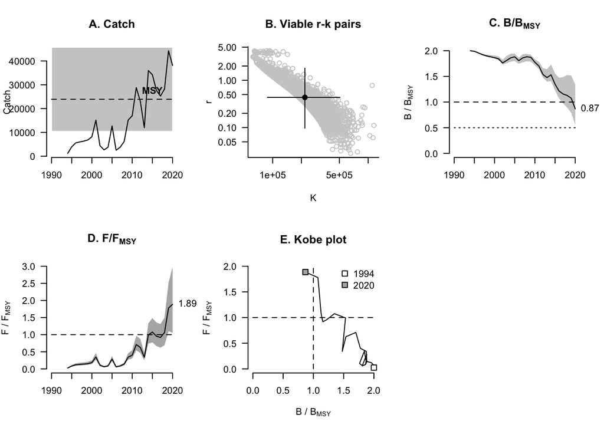

```r
plot_dlm(m2)
```

De igual manera, la trayectoria de la biomasa estimada es:

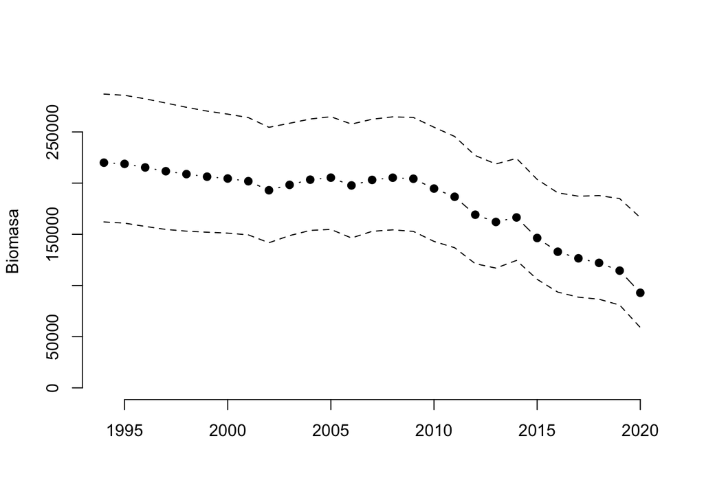

```r
m2.Bt = m2$ref_ts$b
m2.Bt_l = m2$ref_ts$b_lo
m2.Bt_h = m2$ref_ts$b_hi
plot(yr, m2.Bt, type="b", bty="n", pch=19,xlab="",ylab="Biomasa",ylim=c(0,max(m2.Bt_h)))
lines(yr, m2.Bt_l, lty=2)
lines(yr, m2.Bt_h, lty=2)
```

Los puntos biológicos de referencia, se obtiene por:

```r
CMSY2_ref_pts = m2[["ref_pts"]]
knitr::kable(CMSY2_ref_pts)
```

| param | q0.025 | q0.25 | q0.5 | q0.75 | q0.975 |
| --- | --- | --- | --- | --- | --- |
| r | 9.70e-02 | 2.66e-01 | 4.35e-01 | 7.04e-01 | 1.80e+00 |
| k | 8.79e+04 | 1.58e+05 | 2.17e+05 | 2.91e+05 | 5.06e+05 |
| msy | 1.04e+04 | 1.90e+04 | 2.39e+04 | 2.88e+04 | 4.58e+04 |
| bmsy | 4.40e+04 | 7.92e+04 | 1.09e+05 | 1.46e+05 | 2.53e+05 |
| fmsy | 4.80e-02 | 1.33e-01 | 2.17e-01 | 3.52e-01 | 9.01e-01 |
| s_final | 2.78e-01 | 3.93e-01 | 4.69e-01 | 5.47e-01 | 7.03e-01 |

Con propósitos comparativos, se puede aplicar el método BTR de Zhou et al. (2017b), a saber:

```r
m3 <- zbrt(year=yr, catch=catch)
```

**Nota**: el método zBRT de Zhou estima la saturación ($S$), esto es $B/k$; i.e.,

$$S = B/k = 0.5B/B_{RMS}$$

A partir de la serie de tiempo de captura se obtiene la saturación $B/k$, i.e.

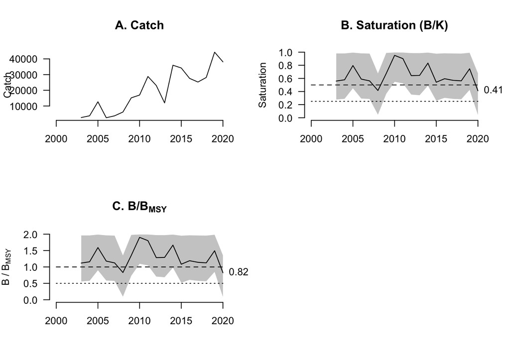

```r
plot_dlm(m3)
```

Para extraer las series de tiempo:

```r
ts <- m3[["ts"]]
knitr::kable(ts)
```

| year | catch | s8 | s38 | s | s_lo | s_hi | bbmsy | bbmsy_lo | bbmsy_hi |
| --- | --- | --- | --- | --- | --- | --- | --- | --- | --- |
| 1994 | 1186 | NA | NA | NA | NA | NA | NA | NA | NA |
| 1995 | 3930 | NA | NA | NA | NA | NA | NA | NA | NA |
| 1996 | 5585 | NA | NA | NA | NA | NA | NA | NA | NA |
| 1997 | 5998 | NA | NA | NA | NA | NA | NA | NA | NA |
| 1998 | 6332 | NA | NA | NA | NA | NA | NA | NA | NA |
| 1999 | 6828 | NA | NA | NA | NA | NA | NA | NA | NA |
| 2000 | 8159 | NA | NA | NA | NA | NA | NA | NA | NA |
| 2001 | 15156 | NA | NA | NA | NA | NA | NA | NA | NA |
| 2002 | 4429 | NA | NA | NA | NA | NA | NA | NA | NA |
| 2003 | 2645 | 0.559 | 0.599 | 0.559 | 0.278 | 0.980 | 1.119 | 0.556 | 1.96 |
| 2004 | 3764 | 0.579 | 0.618 | 0.579 | 0.289 | 0.981 | 1.158 | 0.578 | 1.96 |
| 2005 | 12707 | 0.796 | 0.789 | 0.796 | 0.450 | 0.993 | 1.592 | 0.899 | 1.99 |
| 2006 | 2517 | 0.589 | 0.610 | 0.589 | 0.293 | 0.982 | 1.179 | 0.585 | 1.96 |
| 2007 | 3743 | 0.562 | 0.581 | 0.562 | 0.287 | 0.978 | 1.124 | 0.573 | 1.96 |
| 2008 | 6160 | 0.415 | 0.429 | 0.415 | 0.047 | 0.675 | 0.830 | 0.094 | 1.35 |
| 2009 | 15199 | 0.676 | 0.640 | 0.676 | 0.365 | 0.988 | 1.352 | 0.731 | 1.98 |
| 2010 | 16977 | 0.951 | 0.729 | 0.951 | 0.548 | 0.995 | 1.903 | 1.097 | 1.99 |
| 2011 | 28814 | 0.901 | 0.726 | 0.901 | 0.524 | 0.994 | 1.802 | 1.048 | 1.99 |
| 2012 | 23079 | 0.642 | 0.580 | 0.642 | 0.353 | 0.986 | 1.285 | 0.707 | 1.97 |
| 2013 | 11955 | 0.645 | 0.572 | 0.645 | 0.343 | 0.985 | 1.291 | 0.687 | 1.97 |
| 2014 | 35975 | 0.834 | 0.669 | 0.834 | 0.488 | 0.993 | 1.667 | 0.977 | 1.99 |
| 2015 | 34218 | 0.542 | 0.547 | 0.542 | 0.260 | 0.977 | 1.083 | 0.520 | 1.95 |
| 2016 | 27586 | 0.595 | 0.577 | 0.595 | 0.303 | 0.983 | 1.191 | 0.607 | 1.97 |
| 2017 | 25267 | 0.571 | 0.503 | 0.571 | 0.288 | 0.980 | 1.142 | 0.576 | 1.96 |
| 2018 | 28175 | 0.563 | 0.447 | 0.563 | 0.282 | 0.978 | 1.125 | 0.565 | 1.96 |
| 2019 | 44288 | 0.747 | 0.574 | 0.747 | 0.425 | 0.991 | 1.494 | 0.850 | 1.98 |
| 2020 | 38109 | 0.411 | 0.421 | 0.411 | 0.043 | 0.677 | 0.823 | 0.085 | 1.35 |

## Ejercicios

### Ejercicio 1

1. Aplique los modelos basados sólo en captura a datos de jibia, *Dosidicus gigas*, que corresponden a registros totales en el Pacífico Suroriental, Area 87 (Payá, 2018). Discuta brevemente los resultados encontrados y comente sobre el estatus del calamar.

## Referencias

Free CM (2018) datalimited2: More stock assessment methods for data-limited fisheries. R package version 0.1.0. https://github.com/cfree14/datalimited2

Froese, R., Demirel, N., Coro, G., Kleisner, K.M., Winker, H. 2017. Estimating fisheries reference points from catch and resilience. Fish and Fisheries 18(3): 506-526. http://onlinelibrary.wiley.com/doi/10.1111/faf.12190/abstract

Payá, I. 2018. Estatus y posibilidades de explotación biológicamente sustentables de los principales recursos pesqueros nacionales al año 2018. Jibia. Informe 3 Consolidado Instituto de Fomento Pesquero. 110 pp. + 4 anexos.

Zhou, S., Punt, A.E., Smith, A.D.M., Ye, Y., Haddon, M., Dichmont, C.M., Smith, D.C. 2017a. An optimised catch-only assessment method for data poor fisheries. ICES Journal of Marine Science 75, 964–976. https://doi.org/10.1093/icesjms/fsx226

Zhou, S., Punt, A.E., Yimin, Y., Ellis, N., Dichmont, C.M., Haddon, M., Smith, D.C., Smith, A.D.M. 2017b. Estimating stock depletion level from patterns of catch history. Fish and Fisheries 18(4), 742–751. https://doi.org/10.1111/faf.12201